# Is Synthetic Turf Causing an Increase in NFL Injuries?

Kristina Lau

2023-11-30

## Introduction

Throughout the NFL’s history, it has always been plagued by injuries. However, the NFL is always striving to improve their player’s safety and as a result has made vast improvements when it comes to player healthcare, recovery, and medical procedures. Despite these efforts, players continue to be injured and, in recent seasons, injuries appear to be increasing with synthetic turf being one of the major player complaints. Is synthetic turf causing an increase in the amount of injuries players are receiving in a season?

# Questions

The questions I will be asking and attempting to answer are:

- Where on the player’s body are the injuries happening the most?
- Which positions get injured more often?
- Is there a relationship between injuries and the type of field stadiums use?
- Is there a way to lessen the amount of injuries in the NFL?

## Packages I Used

```r
#helps tidy data
library(tidyr)
#helps to wrangle data
library(dplyr)
#helps with data import, tidying, manipulation and data visualization
library(tidyverse)
#helps create complex graphs and plots
library(ggplot2)
#will help with dates and times
library(scales)
#to help create visually appealing graphs
library(viridis)
```

## Key Terms

### Injury Data File

- PlayerKey - Uniquely identifies a player with a five-digit numerical key
- GameID - Uniquely identifies a player’s games(not strictly in temporal order)
- PlayKey - Identifies a player’s plays within a game(in sequential order)
- BodyPart - Identifies the injured body part(Knee, Ankle, Foot, etc.)
- Surface - Identifies the playing surface at time of injury(Natural or Synthetic)
- DM_M1 - One-Hot Encoding indicating 1 or more days missed due to injury
- DM_M7 - One-Hot Encoding indicating 7 or more days missed due to injury
- DM_M28 - One-Hot Encoding indicating 28 or more days missed due to injury
- DM_M42 - One-Hot Encoding indicating 42 or more days missed due to injury

### Play List

- PlayerKey - Uniquely identifies a player with a five-digit numerical key
- GameID - Uniquely identifies a player’s games(not strictly in temporal order)
- PlayKey - Identifies a player’s plays within a game(in sequential order)
- RosterPosition - provides the player’s roster position
- PlayerDay - an integer sequence that reflects the timeline of a player’s participation in games; use this field to sequence player participation
- PlayerGame - uniquely indentifies a player’s games; matches the last integer of the GameID(not strictly in temporal order of game occurrence)
- StadiumType - a free text description of the type of stadium(open, closed dome, etc.)
- FieldType - a categorical description of the field type(Natural or Synthetic)
- Temperature - on-field temperature at the start of the game(not always available - for closed dome/indoor stadiums this field may not be relevant as the temperature and weather are controlled)
- Weather - a free text descroption of the weather at the stadium(for some games this isn’t always available)
- PlayType - categorical description of play type(pass, run, kickoff, etc.)
- Position - a categorical variable denoting the player’s position for the play(RB, QB, LB, etc.)
- PositionGroup - a categorical variable denoting the player’s position group for the position held during the play ***

## The Data

[Here is the Link for the Data](https://www.kaggle.com/competitions/nfl-playing-surface-analytics/data?select=PlayerTrackData.csv)

The data I will be using is from the website Kaggle. They were provided for an official NFL Data competition and provide information regarding player injuries throughout two seasons.

- Injury Record: This csv file contains information on 105 lower-limb injuries that occured during regular season games over two seasons. Injuries can be linked to specific records in a player history using the PlayerKey, GameID, and PlayKey fields.
- Play List: The play list file contains the details for 267, 005 player-plays that make up the dataset. Each play is indexed by PlayKey, GameID, and PlayKey fields. Details about the game and play include the player’s assigned roster position, stadium type, field type, weather, play type, position for the play, and position group.

For these datasets, I will be reading them in and assigning them to new variables. I will also be displaying the heads of the datasets.

```r
injury_record <- read.csv("InjuryRecord - InjuryRecord.csv")
head(injury_record)
```

```
##   PlayerKey  GameID    PlayKey BodyPart   Surface DM_M1 DM_M7 DM_M28 DM_M42
## 1     39873 39873-4 39873-4-32     Knee Synthetic     1     1      1      1
## 2     46074 46074-7 46074-7-26     Knee   Natural     1     1      0      0
## 3     36557 36557-1 36557-1-70    Ankle Synthetic     1     1      1      1
## 4     46646 46646-3 46646-3-30    Ankle   Natural     1     0      0      0
## 5     43532 43532-5 43532-5-69    Ankle Synthetic     1     1      1      1
## 6     41145 41145-2 41145-2-60     Knee   Natural     1     0      0      0
```

```r
play_list <- read.csv("PlayList - PlayList.csv")
head(play_list)
```

```
##   PlayerKey  GameID   PlayKey RosterPosition PlayerDay PlayerGame StadiumType
## 1     26624 26624-1 26624-1-1    Quarterback         1          1    Outdoors
## 2     26624 26624-1 26624-1-2    Quarterback         1          1    Outdoors
## 3     26624 26624-1 26624-1-3    Quarterback         1          1    Outdoors
## 4     26624 26624-1 26624-1-4    Quarterback         1          1    Outdoors
## 5     26624 26624-1 26624-1-5    Quarterback         1          1    Outdoors
## 6     26624 26624-1 26624-1-6    Quarterback         1          1    Outdoors
##   FieldType Temperature        Weather PlayType PlayerGamePlay Position
## 1 Synthetic          63 Clear and warm     Pass              1       QB
## 2 Synthetic          63 Clear and warm     Pass              2       QB
## 3 Synthetic          63 Clear and warm     Rush              3       QB
## 4 Synthetic          63 Clear and warm     Rush              4       QB
## 5 Synthetic          63 Clear and warm     Pass              5       QB
## 6 Synthetic          63 Clear and warm     Rush              6       QB
##   PositionGroup
## 1            QB
## 2            QB
## 3            QB
## 4            QB
## 5            QB
## 6            QB
```

# Cleaning up the Data

I manually cleaned up the data in the .csv files by fixing spelling mistakes as there were many typos.

I also created a left join and merged together the PlayList and InjuryRecord csv files so that way I can filter out the necessary data I need. The new dataset I made is called full_data.

Something of note that I did was I manually went into the full_data file and changed the FS and SS categories into S. This helps to merge all of them into 1 position because both FS and SS are considered the same position.

# Where on the player’s body are the injuries happening the most?

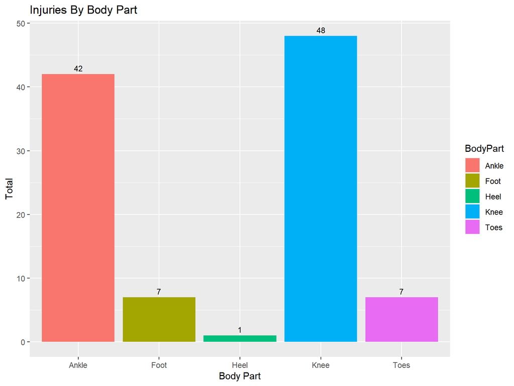

I plotted the data and put them into a bar graph so we can see all of the different injuries. For this bar graph I used ‘BodyPart’ for my x-axis and the total injuries are the y-axis.

Here are the different types of injuries in the dataset. There are 105 total injuries with all of them happening to the lower limbs. What is interesting about this data is that the majority of the injuries happened to the knees and ankles. With both of them making up 86% of the total injuries. The fact that all of the injuries are lower limb injuries suggests that there could be a relationship between player injuries and the field types they play on. However, we currently lack substantial evidence that could link player injuries directly to specific field types.

# Which positions get injured more often?

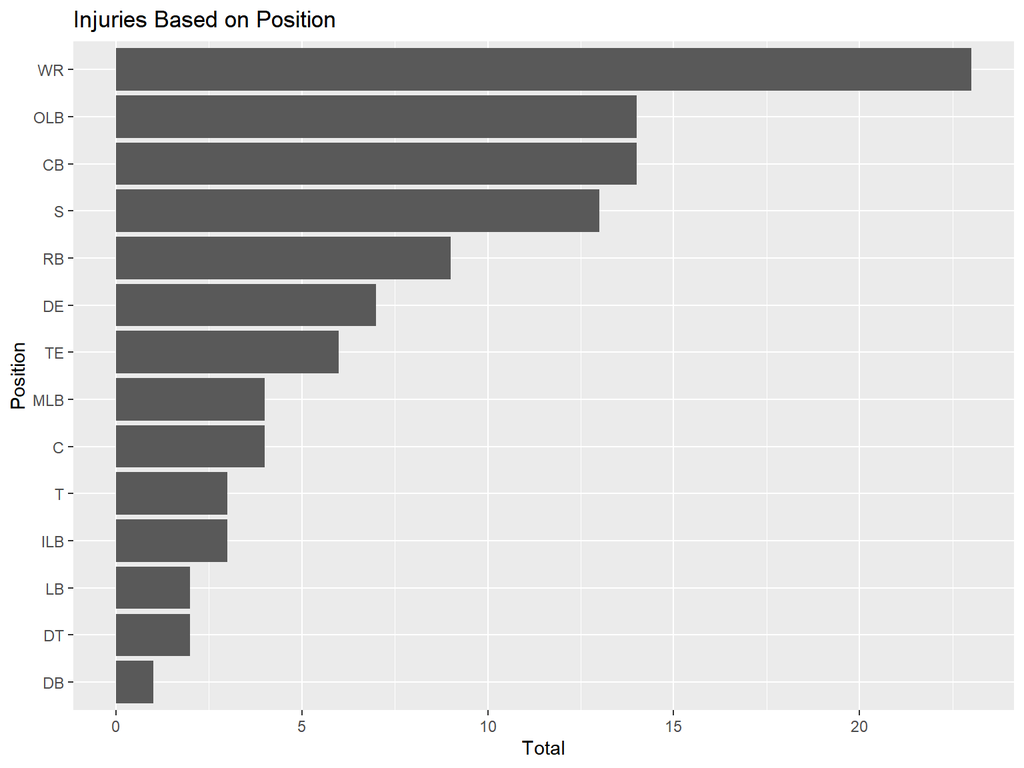

Next, I created a horizontal bar graph to analyze the rate of injuries across different positions. The y-axis represents ‘Position,’ while the x-axis corresponds to the total number of injuries.

Upon examining the graph, it is evident that wide receivers experience the highest rate of injuries while defensive backs experience the lowest rate of injuries. What is interesting to note is that wide receivers, outside linebackers, and cornerbacks are the top 3 positions that tend to be injured the most. What is interesting about these 3 positions is that they all cover each other. Wide receivers can be covered by either cornerbacks or outside linebackers but they are usually covered by cornerbacks. Now that we have determined which positions are being injured the most let’s move on and see the relationship between injuries and the type of fields they happen on.

# Is there a relationship between injuries and the type of field stadiums use?

### Natural grass vs Synthetic Turf

I will be comparing the injuries that happen on natural grass vs synthetic turf. This will allow us to see which type of field the injuries are happening the most on. For this comparison I will be plotting a bar graph and using the ‘Surface’ category as the x-axis and then using the total amount of injuries as the y-axis.

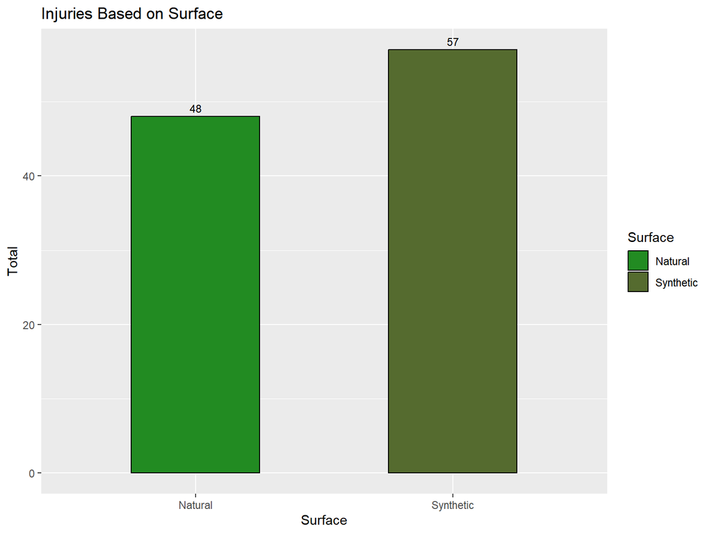

According to the data from our dataset, injuries appear to happen more often on synthetic turf than natural grass. With 54.29% of the injuries happening on synthetic turf.

### Injuries per Position

For this graph, I wanted to see which positions were being injured on which field type. I created a facet wrap for each position with the x-axis as the field type and the count as the y-axis.

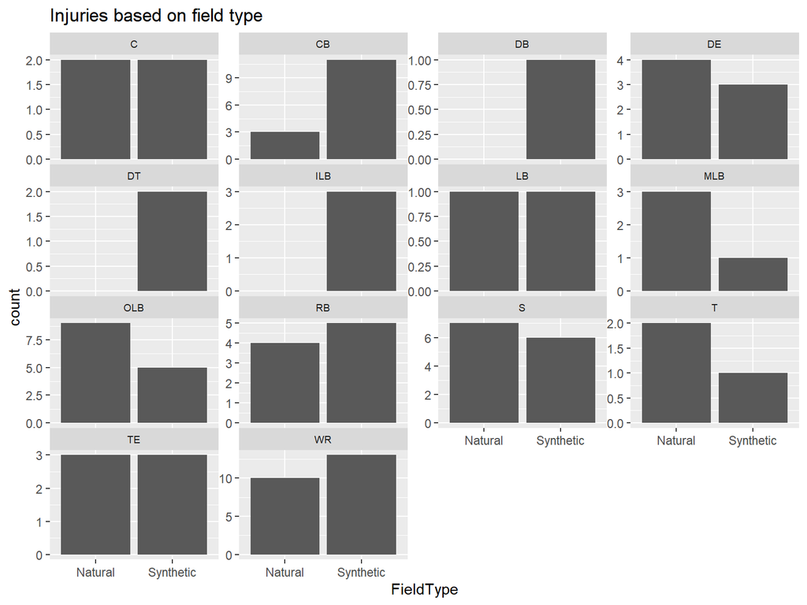

# Synthetic Turf

Now that we’ve acknowledged the elevated risk of injuries on Synthetic Turf, let’s delve into a brief history of synthetic turf to enhance our understanding of this playing surface.

Synthetic turf, also known as artificial turf, is a specially designed surface composed of synthetic fibers that emulate the appearance and texture of natural grass. Modern iterations of synthetic turf predominantly utilize materials such as nylon, polypropylene, and recycled crumb rubber. Players often attest to experiencing enhanced traction and cutting ability when playing on synthetic turf compared to natural grass. However, this also leads to more lower limb injuries that wouldn’t happen otherwise.

The adoption of synthetic turf in the NFL gained prominence when the Seattle Seahawks became the first team to install it on their home field in 2002. This move sparked a trend, leading to more team owners opting for synthetic turf. As of 2021, 15 out of 30 NFL stadiums feature synthetic turf. It’s worth noting that the shared stadiums of the New York Giants and Jets, as well as the Los Angeles Chargers and Rams, contribute to the total count.

Despite the rising popularity of synthetic turf, research reveals that the installation and maintenance costs exceed those of natural grass fields. This prompts the question: Why do more NFL stadiums choose synthetic turf over natural grass? Because its easier to maintain and lasts longer than natural grass.

Owners favoring synthetic turf argue that it proves cost-efficient and enhances player performance. The surface is easier to maintain and boasts a longer lifespan than natural grass. Despite concerns about an increased risk of injuries, owners who believe in the benefits of synthetic turf are likely to continue its use, sometimes against the preferences of players and fans.

# Is there a way to lessen the amount of injuries in the NFL?

Yes, there is a way to lessen the amount of injuries in the NFL and that is for all NFL stadiums to use natural grass. While there isn’t a way to completely get rid of injuries, the next best thing we can do is to try to lessen the amount of injuries for the player’s safety. If the NFL wishes to improve the health and safety of their players, they need to consider doing all they can for them which includes changing the fields back to natural grass.

# Summary